# Eye Movements

Bayesian models of reading prequestioned, non-prequestioned and no-prequestion sentences

Author

Jason Geller

Published

October 27, 2026

## What this document does

One row per participant × target sentence (5 Polio and 5 TB target sentences, each containing the answer to one question; `R/data.R`). Durations are in s/word (the models’ scale; the manuscript reports ms/word). Measures and models:

| Measure | Family (link) | Prior SD *s* of every pairwise difference |
| --- | --- | --- |
| Total gaze duration | ex-Gaussian (`cogmod::cogmod_exgaussian`; μ identity, σ and τ softplus); Status/Group and Topic on μ and τ | μ: 0.1 s/word; τ: 0.5 |
| Re-reading time (after moving on to later text; sentences re-read only) | Gamma (log) | 0.5 |
| Regression-in (look-back: returned to from later text, 0/1) | Bernoulli (logit) | 1.5 |
| First-pass reading: selective regression-path duration | ex-Gaussian, as for total gaze duration | μ: 0.1 s/word; τ: 0.5 |

Two sets of models, as for the final test: **status models** (Prequestioned, Non-prequestioned, no-prequestion + Topic; comparisons with no-prequestion) and **Group × Topic models** (Polio − TB within each group, and the interaction contrast; for look-backs, their Bayes factors are on the response scale, the scale of the estimates). Random effects: the maximal structure warranted by the design, by-participant intercepts and Topic slopes and by-sentence intercepts and Status (or Group) slopes (every sentence was read in all three statuses and by all three groups). Equal-prior contrasts, Savage–Dickey Bayes factors from `modelbased` comparisons, and cached fits as described in `R/bayes_helpers.R`.

**Why cogmod only for total gaze duration.** cogmod’s ex-Gaussian is the classical μ, σ, τ parameterisation, as preregistered. cogmod’s other duration families are response-time models (e.g. `cogmod_gamma()` is a shifted Gamma parameterised by shape and scale), whose parameters are not mean reading time. Re-reading time uses brms’s mean-parameterised Gamma, so its effects are effects on mean reading time. The ex-Gaussian could not be estimated for re-reading time (σ collapsed: many single brief fixations).

**First-pass reading time.** The preregistered first-pass duration (from first entering the sentence until first leaving it) is bimodal: about half of first passes are cut short after a few fixations by a brief return to the preceding line, so it mixes complete first readings (median about 3 s) with interrupted ones (median about 0.4 s), and no single distribution (ex-Gaussian, Gamma, lognormal) describes it. First-pass reading is therefore measured as selective regression-path duration (`go_past`; Schotter & Dillon, 2025): fixations on the sentence from first entering it until the reader first moves on to later text, so brief returns to earlier text do not end it and time spent on earlier text is not counted. Its distribution is unimodal and the ex-Gaussian describes it closely, so it is analysed like total gaze duration (μ and τ). The model key remains `first_pass`.

*Naming:* the paper calls the group without prequestions the **no-prequestion** condition; in the data and code it is labelled `Control`.

## Setup

```r
library(here)
fit_settings <- list(chains = 4, iter = 11000, warmup = 1000, adapt_delta = 0.95, refit = FALSE)
if (exists("params")) {
  fit_settings <- modifyList(fit_settings, params[intersect(names(params), names(fit_settings))])
}
source(here("R", "setup.R"))
source(here("R", "data.R"))
source(here("R", "bayes_helpers.R"))
```

## Data

```r
# Durations in s/word; re-reading time is NA for sentences not re-read after the reader
# moved on (whether they were re-read is the look-back measure)
et <- dat_status |>
  mutate(first_pass = go_past,   # first-pass reading = selective regression-path duration
         across(c(total_fix, first_pass, reread_time), \(x) x / 1000)) |>
  select(participant, sentence, condition, topic, status,
         total_fix, first_pass, reread_time, regressed_in)
et_dv <- \(dv) equal_prior(droplevels(et[!is.na(et[[dv]]), ]))
et_dv_cond <- \(dv) cond_coding(et_dv(dv))

count(et, status, topic)
```

| status | topic | n |
| --- | --- | --- |
| Prequestioned | Polio | 225 |
| Prequestioned | TB | 230 |
| Non-prequestioned | Polio | 230 |
| Non-prequestioned | TB | 225 |
| Control | Polio | 235 |
| Control | TB | 235 |

## Models

```r
m_et <- list(
  total_fix = fit_brm(
    bf(as.formula(paste("total_fix ~ status + topic +", re_et)),
       sigma ~ 1 + (1 | participant),
       as.formula(paste("tau ~ status + topic +", re_et))),
    et_dv("total_fix"),
    cogmod_exgaussian(),   # cogmod's default links: identity for mu, softplus for sigma and tau
    pr_exg, "bayes_status_total_fix", stanvars = cogmod_exgaussian_stanvars()),
  reread_time = fit_brm(as.formula(paste("reread_time ~ status + topic +", re_et)),
                        et_dv("reread_time"), Gamma(link = "log"), pr_gamma,
                        "bayes_status_reread_after"),
  regressed_in = fit_brm(as.formula(paste("regressed_in ~ status + topic +", re_et)),
                         et_dv("regressed_in"), bernoulli(), pr_logit, "bayes_status_regressed_in"),
  first_pass = fit_brm(
    bf(as.formula(paste("first_pass ~ status + topic +", re_et)),
       sigma ~ 1 + (1 | participant),
       as.formula(paste("tau ~ status + topic +", re_et))),
    et_dv("first_pass"), cogmod_exgaussian(), pr_exg, "bayes_status_go_past_exg",
    stanvars = cogmod_exgaussian_stanvars())
)

m_topic <- list(
  total_fix = fit_brm(
    bf(as.formula(paste("total_fix ~ condition * topic +", re_et_cond)),
       sigma ~ 1 + (1 | participant),
       as.formula(paste("tau ~ condition * topic +", re_et_cond))),
    et_dv_cond("total_fix"), cogmod_exgaussian(), pr_exg, "bayes_cond_topic_total_fix",
    stanvars = cogmod_exgaussian_stanvars()),
  reread_time = fit_brm(as.formula(paste("reread_time ~ condition * topic +", re_et_cond)),
                        et_dv_cond("reread_time"), Gamma(link = "log"), pr_gamma,
                        "bayes_cond_topic_reread_after"),
  regressed_in = fit_brm(as.formula(paste("regressed_in ~ condition * topic +", re_et_cond)),
                         et_dv_cond("regressed_in"), bernoulli(), pr_logit,
                         "bayes_cond_topic_regressed_in"),
  first_pass = fit_brm(
    bf(as.formula(paste("first_pass ~ condition * topic +", re_et_cond)),
       sigma ~ 1 + (1 | participant),
       as.formula(paste("tau ~ condition * topic +", re_et_cond))),
    et_dv_cond("first_pass"), cogmod_exgaussian(), pr_exg, "bayes_cond_topic_go_past_exg",
    stanvars = cogmod_exgaussian_stanvars())
)
```

## Diagnostics

```r
diag_tab <- diag_table(c(m_et, set_names(m_topic, paste0(names(m_topic), " (Group × Topic)"))))
diag_tab
```

| model | divergences | max_rhat | min_ess_bulk |
| --- | --- | --- | --- |
| total_fix | 0 | 1.000959 | 5481.380 |
| reread_time | 0 | 1.000431 | 7766.958 |
| regressed_in | 0 | 1.000817 | 8593.890 |
| first_pass | 0 | 1.000939 | 4959.574 |
| total_fix (Group × Topic) | 0 | 1.000637 | 5617.812 |
| reread_time (Group × Topic) | 0 | 1.000497 | 8333.502 |
| regressed_in (Group × Topic) | 0 | 1.000680 | 8956.833 |
| first_pass (Group × Topic) | 0 | 1.000712 | 5196.388 |

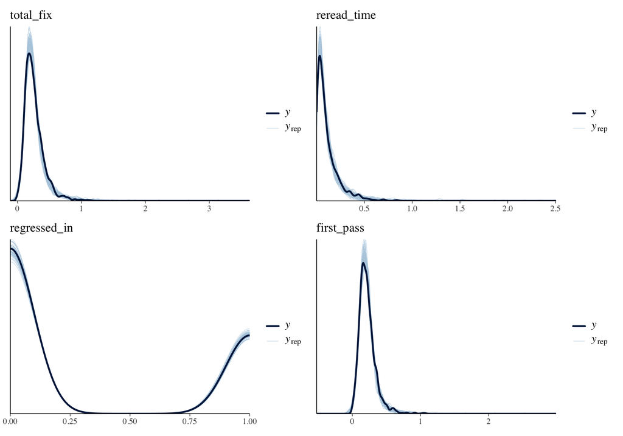

Figure 1

```r
patchwork::wrap_plots(imap(m_et, \(m, nm) pp_check(m, ndraws = 50) + labs(title = nm)), ncol = 2)
```

## Status models: prequestioned and non-prequestioned vs. no-prequestion

Bayes factors on the link scale (τ and the expected re-reading time on the response scale, the latter at the population level); estimates on the response scale.

```r
bf_tab <- bf_table(m_et)
est_tab <- contrasts_by(m_et)
means_tab <- means_by(m_et, "status")
means_draws <- mean_draws_by(m_et, "status")
bf_tab |> transmute(model, parameter, comparison, BF10, BF01) |> kable(digits = 2)
```

| model | parameter | comparison | BF10 | BF01 |
| --- | --- | --- | --- | --- |
| total_fix | mu | Prequestioned - Control | 0.07 | 14.26 |
| total_fix | mu | Non-prequestioned - Control | 0.06 | 15.41 |
| total_fix | tau | Prequestioned - Control | 31.07 | 0.03 |
| total_fix | tau | Non-prequestioned - Control | 0.27 | 3.72 |
| reread_time | mu | Prequestioned - Control | 9.49 | 0.11 |
| reread_time | mu | Non-prequestioned - Control | 0.18 | 5.56 |
| regressed_in | mu | Prequestioned - Control | 1.67 | 0.60 |
| regressed_in | mu | Non-prequestioned - Control | 0.16 | 6.12 |
| first_pass | mu | Prequestioned - Control | 0.08 | 12.13 |
| first_pass | mu | Non-prequestioned - Control | 0.08 | 12.27 |
| first_pass | tau | Prequestioned - Control | 1.25 | 0.80 |
| first_pass | tau | Non-prequestioned - Control | 0.22 | 4.62 |

```r
est_tab
```

| Level1 | Level2 | ROPE_CI | Mean | CI_low | CI_high | pd | ROPE_low | ROPE_high | ROPE_Percentage | model | parameter |
| --- | --- | --- | --- | --- | --- | --- | --- | --- | --- | --- | --- |
| Prequestioned | Control | 0.95 | 2.785896e-03 | -0.011400394 | 0.017037971 | 0.647025 | -0.1 | 0.1 | 1.0000 | total_fix | mu |
| Non-prequestioned | Control | 0.95 | 2.300834e-03 | -0.011236824 | 0.015924698 | 0.630975 | -0.1 | 0.1 | 1.0000 | total_fix | mu |
| Prequestioned | Control | 0.95 | 3.387730e-02 | 0.011922624 | 0.056429401 | 0.999125 | -0.1 | 0.1 | 1.0000 | total_fix | tau |
| Non-prequestioned | Control | 0.95 | -4.710710e-03 | -0.024032929 | 0.014739782 | 0.684825 | -0.1 | 0.1 | 1.0000 | total_fix | tau |
| Prequestioned | Control | 0.95 | 2.920160e-02 | 0.007846018 | 0.051176393 | 0.996050 | -0.1 | 0.1 | 1.0000 | reread_time | mu |
| Non-prequestioned | Control | 0.95 | 2.799356e-04 | -0.019839415 | 0.020597136 | 0.511725 | -0.1 | 0.1 | 1.0000 | reread_time | mu |
| Prequestioned | Control | 0.95 | 7.328009e-02 | 0.023673361 | 0.122360849 | 0.998050 | -0.1 | 0.1 | 0.8765 | regressed_in | mu |
| Non-prequestioned | Control | 0.95 | -1.336674e-02 | -0.061291418 | 0.034855746 | 0.706250 | -0.1 | 0.1 | 1.0000 | regressed_in | mu |
| Prequestioned | Control | 0.95 | -4.982767e-03 | -0.019645883 | 0.009423139 | 0.749600 | -0.1 | 0.1 | 1.0000 | first_pass | mu |
| Non-prequestioned | Control | 0.95 | -4.902725e-03 | -0.018962216 | 0.009190169 | 0.754600 | -0.1 | 0.1 | 1.0000 | first_pass | mu |

[output cut: 2 more lines]

## Group × Topic

```r
# look-backs (a probability): Bayes factors on the response scale, the scale of the estimates
bf_topic_tab <- bf_table(m_topic, topic_draws, response_scale = "regressed_in")
est_topic_tab <- topic_estimates(m_topic)
means_topic_tab <- means_by(m_topic, c("condition", "topic")) |> add_status()
means_topic_draws <- mean_draws_by(m_topic, c("condition", "topic")) |> add_status()
bf_topic_tab |> transmute(model, parameter, comparison, BF10, BF01) |> kable(digits = 2)
```

| model | parameter | comparison | BF10 | BF01 |
| --- | --- | --- | --- | --- |
| total_fix | mu | Polio - TB (Polio group) | 0.16 | 6.36 |
| total_fix | mu | Polio - TB (TB group) | 0.11 | 9.49 |
| total_fix | mu | Polio - TB (Control group) | 1.90 | 0.53 |
| total_fix | mu | Interaction (Polio group - TB group) | 0.11 | 9.06 |
| total_fix | tau | Polio - TB (Polio group) | 4.24 | 0.24 |
| total_fix | tau | Polio - TB (TB group) | 5.07 | 0.20 |
| total_fix | tau | Polio - TB (Control group) | 2.27 | 0.44 |
| total_fix | tau | Interaction (Polio group - TB group) | 108.78 | 0.01 |
| reread_time | mu | Polio - TB (Polio group) | 2.99 | 0.33 |
| reread_time | mu | Polio - TB (TB group) | 0.27 | 3.64 |
| reread_time | mu | Polio - TB (Control group) | 2.51 | 0.40 |
| reread_time | mu | Interaction (Polio group - TB group) | 4.79 | 0.21 |
| regressed_in | mu | Polio - TB (Polio group) | 10.73 | 0.09 |
| regressed_in | mu | Polio - TB (TB group) | 22371746.21 | 0.00 |
| regressed_in | mu | Polio - TB (Control group) | 58.69 | 0.02 |
| regressed_in | mu | Interaction (Polio group - TB group) | 63.06 | 0.02 |
| first_pass | mu | Polio - TB (Polio group) | 0.21 | 4.69 |
| first_pass | mu | Polio - TB (TB group) | 0.24 | 4.17 |
| first_pass | mu | Polio - TB (Control group) | 17.03 | 0.06 |
| first_pass | mu | Interaction (Polio group - TB group) | 0.11 | 9.40 |
| first_pass | tau | Polio - TB (Polio group) | 0.70 | 1.44 |
| first_pass | tau | Polio - TB (TB group) | 0.50 | 2.01 |
| first_pass | tau | Polio - TB (Control group) | 39.44 | 0.03 |
| first_pass | tau | Interaction (Polio group - TB group) | 1.68 | 0.59 |

```r
est_topic_tab
```

| comparison | Mean | CI_low | CI_high | pd | model | parameter |
| --- | --- | --- | --- | --- | --- | --- |
| Polio - TB (Polio group) | 0.012788279 | -0.006567200 | 0.0322077375 | 0.901000 | total_fix | mu |
| Polio - TB (TB group) | 0.009283726 | -0.011033654 | 0.0293679404 | 0.817275 | total_fix | mu |
| Polio - TB (Control group) | 0.025331175 | 0.006126200 | 0.0443152344 | 0.995200 | total_fix | mu |
| Interaction (Polio group - TB group) | 0.003504553 | -0.023367769 | 0.0305253184 | 0.600800 | total_fix | mu |
| Polio - TB (Polio group) | 0.033192355 | 0.004566667 | 0.0626996644 | 0.988500 | total_fix | tau |
| Polio - TB (TB group) | -0.036899375 | -0.068604672 | -0.0060862587 | 0.989875 | total_fix | tau |
| Polio - TB (Control group) | -0.027887837 | -0.055866644 | -0.0009860985 | 0.978625 | total_fix | tau |
| Interaction (Polio group - TB group) | 0.070091730 | 0.029222807 | 0.1119807969 | 0.999475 | total_fix | tau |
| Polio - TB (Polio group) | 0.032206976 | 0.001467246 | 0.0644962977 | 0.979900 | reread_time | mu |
| Polio - TB (TB group) | -0.021810813 | -0.054119837 | 0.0113164501 | 0.906700 | reread_time | mu |

[output cut: 14 more lines]

## Prior sensitivity

```r
sens_tab <- sens_table(c(m_et, set_names(m_topic, paste0(names(m_topic), " (Group × Topic)"))))
sens_tab
```

| variable | prior | likelihood | diagnosis | model |
| --- | --- | --- | --- | --- |
| b_Intercept | 0.006680968 | 0.08143359 | no issue | total_fix |
| b_sigma_Intercept | 0.012359012 | 0.90434592 | no issue | total_fix |
| b_tau_Intercept | 0.017316857 | 0.12852427 | no issue | total_fix |
| b_status1 | 0.004483291 | 0.06961147 | no issue | total_fix |
| b_status2 | 0.006229011 | 0.11059776 | no issue | total_fix |
| b_topic1 | 0.008212629 | 0.03468207 | no issue | total_fix |
| b_tau_status1 | 0.012409482 | 0.04450435 | no issue | total_fix |
| b_tau_status2 | 0.032414597 | 0.04641466 | no issue | total_fix |
| b_tau_topic1 | 0.035207096 | 0.04869816 | no issue | total_fix |
| b_Intercept | 0.028536155 | 0.22088457 | no issue | reread_time |

[output cut: 54 more lines]

## Results file

```r
save_results(list(diag = diag_tab, bf = bf_tab, est = est_tab, means = means_tab,
                  means_draws = means_draws, bf_topic = bf_topic_tab, est_topic = est_topic_tab,
                  means_topic = means_topic_tab, means_topic_draws = means_topic_draws,
                  sens = sens_tab,
                  n_draws = nrow(posterior::as_draws_df(m_et$first_pass))),
             here("analysis", "results_eye_tracking.rds"))
```